# Regularization

### `! git clone https://github.com/ds4e/regularization`

## Introduction

- We learned the Bias-Variance trade-off: $$ \text{Expected Loss} = \text{Bias-squared} + \text{Predictor Variance} + \text{Irreducible Error} $$
- More complex models have lower bias, but higher variance, and this makes the expected loss higher
- We can use $k$-Fold Cross Validation to evaluate how good a model is; we can compare models using $k$-fCV
- But there's something missing. If you have $L$ variables, there are $2^L$ possible models. That's intractable. How do you tame your wildest feature space?
- How do we reduce model variance in a deliberate, controlled way?

## Regularization

- To control the complexity of the model, we can do something simple: "Charge" the model for "buying" larger slope coefficients, that boosts the error
- For each unit of coefficient, $(b_0, ..., b_L)$, the model has to "pay" $\alpha$ as a penalty
- This makes it literal: More complex models are more expensive
- We pick the $\alpha$ term using cross validation to minimize the MSE (or maximize accuracy)

## Regularization

- How do we impose this cost? It depends. We want to penalize our mean squared error, which means increasing it, in proportion to the amount of coefficient we "purchase"
- We can add the absolute value penalty (LASSO), $$ MSE(b) + \alpha \left( |b_1| + |b_2| + ... + |b_L| \right) $$ or the squared penalty (Ridge) $$ MSE(b) + \alpha \left( b_1^2 + b_2^2 + ... + b_L^2 \right) $$ and "charge" the model $\alpha$ for each unit of coefficient or squared-unit of coefficient it wants to purchase
- This forces the model to pick more predictive variables and reduce the size of coefficients, resulting in interpretable and more reliable models
- In principle, you could make other choices, but these are the most popular by far

## Picking $\alpha$

- Notice: if $\alpha=0$, we're just doing linear regression, so this generalizes linear regression
- If $\alpha$ is big enough, all the coefficients will be zero, because none of them will provide enough predictive power to justify the cost
- In the middle, somewhere, is a "good" $\alpha$ that we pick by cross validation

## Why?

- If your predictor is $$ \hat{y} = \hat{b}_0 + \sum_{\ell=1}^L \hat{b}_\ell x_{i\ell}, $$ then shrinking the coefficients $b$ towards 0 forces the model to have a lower variance, because smaller coefficients means the same changes in $x$ lead to smaller changes in your prediction $\hat{y}$
- This is the logic of the bias-variance trade-off: Regularization provides a way to reduce model variance in a principled, data-driven way

## Outline

1. Fitting the Penalized Model
2. Cross validating the Cost Hyperparameter, $\alpha$

# 1. Fitting the Penalized Model

## Solving with the Penalty

- So we have two technologies here, Ridge and Lasso Regression, and they're both great
- Let's use both them, and see what we get
- I am overly effusive about the Lasso, but Ridge is also great

## Data Cleaning

- Because of the penalty $\alpha |b|$, you "probably always" want to $z$-score normalize your **numeric** variables (but not **dummy/one-hot encoded** variables)
- The cost function makes you compare your variables indirectly by considering which ones have the most explanatory power on the margin; changing variable scales can artificially boost this comparison
- The variables scales themselves impact the mathematical interpretation of $\alpha$ and can create instability

## Getting Started with the LASSO

- We'll look at Cardiac failure data
- We're doing the LASSO, so our objective function is $$ \frac{1}{n} \sum_{i=1}^n (y_i - b \cdot x_i)^2 + \alpha (|b_1| + |b_2| + ... + |b_L|) $$ and we'll vary $\alpha$ to see how it affects the solution
- In SciKit, it's as easy as `from sklearn.linear_model import Lasso`

```python
import numpy as np
import matplotlib.pyplot as plt
import pandas as pd
import seaborn as sns

from sklearn.linear_model import Lasso

mse = lambda y_test,y_hat: np.sum( (y_test-y_hat) ** 2 )/len(y_hat)
z_score = lambda x: (x-x.mean())/x.std()

df = pd.read_csv('./data/CardiacPatientData.csv')
print(df.head())

features = ['SBP', 'DBP', 'HR', 'RR', 'BT', 'SpO2', 'Age', 'Gender', 'GCS', ]
X = (df.loc[:,features]).apply(z_score)
y = df['Outcome']
```

```
   ID  SBP  DBP  HR  RR  BT  SpO2  Age  Gender  GCS     Na    K     Cl  Urea  \
0   1  163   95  90  18  98    98   66       1   15  139.0  4.0  105.0  41.0
1   1  134   85  85  15  98    98   66       1   15  139.0  4.0  105.0  41.0
2   1  121   77  80  19  98    98   66       1   15  139.0  4.0  105.0  41.0
3   1  103   78  70  16  98    98   66       1   15  139.0  4.0  105.0  41.0
4   1   96   70  59  13  98    98   66       1   15  139.0  4.0  105.0  41.0

   Ceratinine  Alcoholic  Smoke  FHCD  TriageScore  Outcome
0        91.0        1.0    1.0   0.0          3.0        1
1        91.0        1.0    1.0   0.0          3.0        1
2        91.0        1.0    1.0   0.0          3.0        1
3        91.0        1.0    1.0   0.0          3.0        1
4        91.0        1.0    1.0   0.0          3.0        1
```

```python
alpha_grid = np.logspace(-3, 0, 15) # Create a grid of alpha values
coefs = []
for alpha in alpha_grid: # For each alpha value,
    model = Lasso(alpha=alpha, max_iter=10_000) # Create a lasso model
    model = model.fit(X,y) # Run the regression
    coefs.append(model.coef_) # Save the slope coefficients
coefs = np.array(coefs) # Cast list of lists to array
var_names = model.feature_names_in_ # Get variable names
```

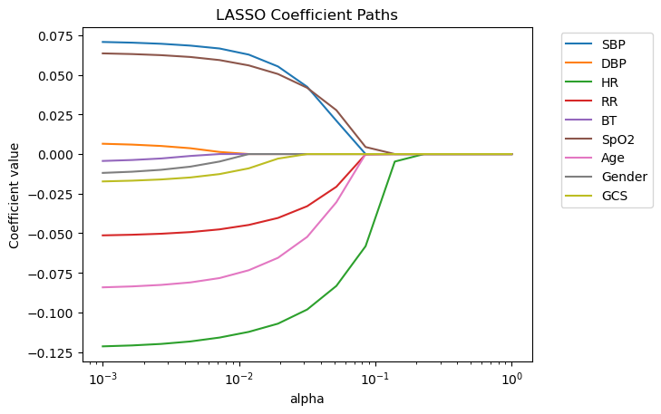

```python
plt.figure()
for i in range(coefs.shape[1]):
    plt.plot(alpha_grid, coefs[:, i], label=var_names[i])
plt.xscale("log")
plt.xlabel("alpha")
plt.ylabel("Coefficient value")
plt.title("LASSO Coefficient Paths")
plt.legend(bbox_to_anchor=(1.05, 1), loc="upper left")
plt.show()
```

## Getting Started with Ridge

- Almost everything is the same, except `from sklearn.linear_model import Ridge`

```python
from sklearn.linear_model import Ridge # Load ridge

alpha_grid = np.logspace(1, 6, 50)

coefs = []
for alpha in alpha_grid:
    model = Ridge(alpha=alpha) # Substitute ridge
    model.fit(X, y)
    coefs.append(model.coef_)

coefs = np.array(coefs)
```

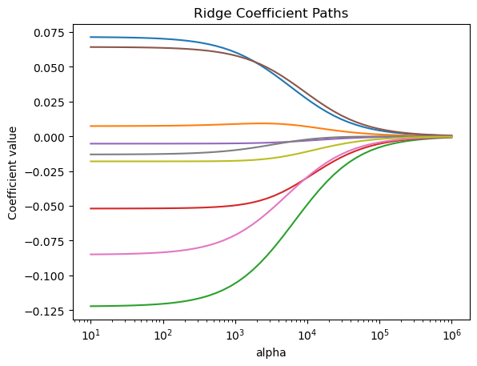

```python
plt.figure()
for i in range(coefs.shape[1]):
    plt.plot(alpha_grid, coefs[:, i])
plt.xscale("log")
plt.xlabel("alpha")
plt.ylabel("Coefficient value")
plt.title("Ridge Coefficient Paths")
plt.show()
```

## Lasso versus Ridge

- Notice how LASSO sends coefs to zero as $\alpha$ increases: It removes variables from the model, and selects a model specification for you
- Notice how Ridge smoothly shrinks all the coefficients towards zero: It never removes a variable completely,
- The LASSO penalty, $\alpha ( |b_1| + |b_2| + ... + |b_L| )$, has points of non-differentiability at 0, or "corners"
- The Ridge penalty, $\alpha ( b_1^2 + b_2^2 + ... + b_L^2 )$, is smooth at zero, and increases faster than $|b_\ell|$
- As a result, LASSO "zeros out" variables and selects a specific model, while Ridge smoothly shrinks all the coefficients towards 0
- Ridge typically performs better, while the LASSO provides more interpretable results

## This Fixes "Big Feature Spaces"

- Now, we can build big feature spaces AND avoid overfitting: Use your `degree=K`, but add regularization to shrink non-performant predictors away
- Now, it's only a matter of computational time/power to build useful models

```python
from sklearn.preprocessing import PolynomialFeatures
expander = PolynomialFeatures(degree=2 ,include_bias=False, interaction_only=True)
X_poly = expander.fit_transform(X)
poly_names = expander.get_feature_names_out()
```

```python
alpha_grid = np.logspace(-3, 0, 15) # Create a grid of alpha values
coefs = []
for alpha in alpha_grid: # For each alpha value,
    model = Lasso(alpha=alpha, max_iter=10_000) # Create a lasso model
    model = model.fit(X_poly,y) # Run the regression
    coefs.append(model.coef_) # Save the slope coefficients
coefs = np.array(coefs) # Cast list of lists to array
```

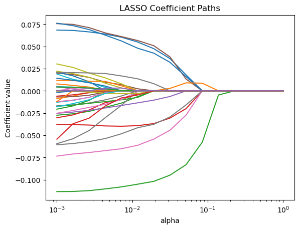

```python
plt.figure()
for i in range(coefs.shape[1]):
    plt.plot(alpha_grid, coefs[:, i], label=poly_names[i]) # Switched in poly_names
plt.xscale("log")
plt.xlabel("alpha")
plt.ylabel("Coefficient value")
plt.title("LASSO Coefficient Paths")
#plt.legend(bbox_to_anchor=(1.05, 1), loc="upper left")
plt.show()
```

# 2. Cross-validating the Cost Hyperparameter, $\alpha$

## Picking the $\alpha$

- The $\alpha$ is a key hyperparameter! How do we pick the cost of purchasing coefficient?
- To decide which penalty value, we cross validate:
  1. Pick a grid of $\alpha$ values
  2. For each $\alpha$ value, use $k$-fCV:
     - Pick the coefficients to minimize $MSE(\hat{b})+\alpha |\hat{b}|$ or $MSE(\hat{b})+\alpha \hat{b}^2$ on the training folds
     - Evaluate $MSE(\hat{b})$ on the test folds and save the estimate
  3. Pick the mean/median value of $MSE(\hat{b})$ for that $\alpha$
  4. Pick the $\alpha$ that the mean/median value of $MSE(\hat{b})$ across the grid
- This automatically generates the paths of the coefficients as the cost $\alpha$ varies, so you can see how variable the coefficients are in the underlying cost

## Scikit Implementation

Of course, that's a complex procedure, and Scikit offers tools for this:

- `model = LassoCV(cv=10, random_state=100).fit(X,y)` will do the $k$-fold cross validation and compute the best model; `model.mse_path_` has the stored mean squared error values, and `mean_mse = model.mse_path_.mean(axis=1)` or `median_mse = model.mse_path_.median(axis=1)` provide the mean/median cross-validated mean squared error
- `alpha, coef_path, _ = lasso_path(X,y,alpha)` creates the data for the plots, like we were doing manually above

```python
import seaborn as sns
from sklearn.linear_model import LassoCV, lasso_path
from sklearn.preprocessing import PolynomialFeatures, StandardScaler

poly = PolynomialFeatures(degree=2, include_bias=False)
X_poly = poly.fit_transform(X)
poly_names = poly.get_feature_names_out()

scaler = StandardScaler()
X_scaled = scaler.fit_transform(X_poly)

alpha_grid = np.logspace(-1.5, .5, num=50)
model = LassoCV(cv=10,
                alphas=alpha_grid,
                random_state=100)
model = model.fit(X_poly, y)

index_star = np.argmin( np.median(model.mse_path_,axis=1) )
alpha_star = model.alphas_[index_star]
```

```
Optimal cost hyperparameter: 0.15627069765469953
```

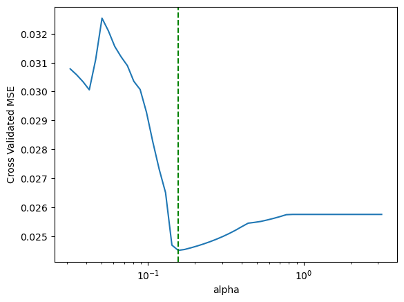

```python
sns.lineplot( x=model.alphas_, y= np.median(model.mse_path_,axis=1) )
plt.axvline(x=alpha_star, color='green', linestyle='--',
            linewidth=1.5)
plt.xscale("log")
plt.xlabel("alpha")
plt.ylabel("Cross Validated MSE")
print(f'Optimal cost hyperparameter: {alpha_star}')
```

```python
coefs = []
for alpha in alpha_grid: # For each alpha value,
    model = Lasso(alpha=alpha, max_iter=10_000) # Create a lasso model
    model = model.fit(X_poly,y) # Run the regression
    coefs.append(model.coef_) # Save the slope coefficients
coefs = np.array(coefs) # Cast list of lists to array
```

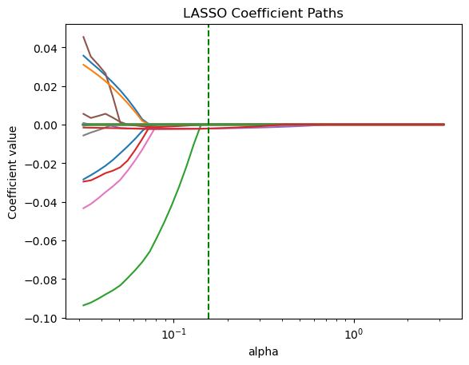

```python
plt.figure()
for i in range(coefs.shape[1]):
    plt.plot(alpha_grid, coefs[:, i], label=poly_names[i]) # Switched in poly_names
plt.xscale("log")
plt.xlabel("alpha")
plt.ylabel("Coefficient value")
plt.title("LASSO Coefficient Paths")
plt.axvline(x=alpha_star, color='green', linestyle='--')
plt.show()
```

## Key Insights

- LASSO will zero coefficients out and automatically select a model for you
- Ridge will shrink all of the coefficients, but not really to zero
- This means LASSO is interpretable like linear regression: It literally decides what variables go in the model
- In practice, however, Ridge typically does better at prediction
- Now, no matter how big the feature space is, in principle you have a way to control your model's tendency to overfit

## Conclusion

- This is one of the most powerful ML toolboxes available
- It is hard to understate how important regularization is; even neural networks typically need regularization to work well
- Now you can tame any feature space: Be creative and exploit your data and machine, and let the regulariation gods sort it out
- These models evolve into neural networks, with thousands and millions and billions and trillions of weights: The secret to stable calculation and robust prediction is finding a way to avoid over-fitting, and the tool is very often regularization
- The LASSO provides an interpretable result, but L2 typically works better in practice
- Your coefficients are explicitly biased, but we are worried about prediction, not inference (and inference with the LASSO is an active area of research)